# Exploring Steiner IBD Model Data

Nikita Telkar

February 11, 2021

### 0.0 Introduction

Here, I’m going to explore the preliminary data files obtained from the Steiner Lab for their IBD disease model project.

### 1.0 Loading Libraries

```r
#data handling packages
library(tibble)
library(here)
library(tidyverse)
library(openxlsx)
library(data.table)
library(rlist)
library(readxl)
library(DT)
library(rmarkdown)
library(knitr)
```

```r
library(factoextra)
library(reshape2)

#analysis packages
library(pheatmap)
library(limma)
library(edgeR)
library(irlba)

#extra packages
library(kableExtra)
library(formatR)
library(janitor)
library(scales)
library(ggpubr)
library(RColorBrewer)
library(showtext)
library(gridExtra)

knitr::opts_chunk$set(fig.showtext = TRUE, fig_retina = 1) #needed to render show_text
knitr::opts_chunk$set(warning = FALSE, error = FALSE, message = FALSE)


font_add_google("Montserrat", "Mont")
showtext_auto()

my_theme <- theme_minimal() +
  theme(plot.title = element_text(family = "Mont", size = 14),
        plot.subtitle = element_text(family = "Mont", size = 12),
        legend.text = element_text(family = "Mont", size = 10),
        axis.title = element_text(family = "Mont", size = 14))

cbPalette <- c("#56B4E9", "#E69F00", "#009E73", "#0072B2", "#D55E00", "#999999")
cbPalette2 <- c("#CC79A7", "#999999", "#E69F00", "#0072B2" , "#009E73", "#D55E00")
#pie(rep(1, 6), col = cbPalette2)
```

### 2.0 Abbreviations and Background

| Abbreviation | Full Form |
| --- | --- |
| US | Untreated |
| RD | Rounds of Damage |
| FliC | Flagellin - bacteria to introduce inflammation |
| ALI | Air liquid interface |

Samples:  
2 sites from 2 donors

1. 59C
2. 75C
- Cells harvested from colon biopsies were grown in a monolayer for 10 days.
- ALI for 7 days (to allow cells to differentiate)
- Add media for 4 hours
- +/- Flic for 3 hours
- Re- ALI for 3 days
- Repeat 5 times

### 3.0 Comparisons

1. Day 10 (undifferentiated baseline) vs Day 7 ALI (differentiated baseline)
   - Day 7 ALI should show genes enriched in cell patterning markers
   - Day 10 would have a more homogeneous profile with upregulated cell growth genes
2. US RD1 vs US RD5
   - Are damage response genes heavily over expressed at RD5?
   - Which genes are downregulated?
3. US RD1 vs FliC RD1
   - Expression profiles should be drastically different with FliC RD1 showing exponentially increased immune/infection response and cell-cycle damage genes
4. FliC RD1 vs Flic RD5
   - Do infection response genes consistently rise or reach a plateau? Or do they stop responding after a while?

Let’s take a look at all of the files that we have, taking Day 10 vs ALI Day 7 as an example:

```r
setwd("Z:/Nikita/Projects/ibd_steiner")

sample <- read.table(here::here("data", "DESeq2", "Day-10_vs_ALI_Day7", "samples.txt"))
sample
```

```
##           V1
## 1       name
## 2 59C-Day-10
## 3 75C-Day-10
## 4 59C-ALI-D7
## 5 75C-ALI-D7
##                                                                                                   V2
## 1                                                                                               file
## 2 /data/scratch/workspace/RunFolder/Analysis/samples/Day10/replicates/59C-Day-10/counts/counts.genes
## 3 /data/scratch/workspace/RunFolder/Analysis/samples/Day10/replicates/75C-Day-10/counts/counts.genes
## 4 /data/scratch/workspace/RunFolder/Analysis/samples/ALID7/replicates/59C-ALI-D7/counts/counts.genes
## 5 /data/scratch/workspace/RunFolder/Analysis/samples/ALID7/replicates/75C-ALI-D7/counts/counts.genes
##      V3             V4
## 1 group Sample_Pair_ID
## 2 Day10          Pair1
## 3 Day10          Pair2
## 4 ALID7          Pair1
## 5 ALID7          Pair2
```

```r
counts <- utils::read.csv(here::here("data", "DESeq2", "Day-10_vs_ALI_Day7", "Day10_vs_ALID7.deseq.counts.csv"))
head(counts)
```

```
##           X X59C.Day.10 X75C.Day.10 X59C.ALI.D7 X75C.ALI.D7
## 1   DDX11L1           0           0           0           0
## 2    WASH7P          16           6          20           4
## 3 MIR6859-3           0           0           0           0
## 4 MIR6859-2           0           0           0           0
## 5 MIR6859-4           0           0           0           0
## 6 MIR6859-1           0           0           0           0
```

```r
res <- utils::read.csv(here::here("data", "DESeq2", "Day-10_vs_ALI_Day7", "Day10_vs_ALID7.deseq.res.csv"))
head(res)
```

```
##           X  GeneName baseMean log2FoldChange    lfcSE         stat    pvalue
## 1   DDX11L1   DDX11L1  0.00000            NaN      NaN          NaN       NaN
## 2    WASH7P    WASH7P 11.20226   0.0001113504 0.225757 0.0004932314 0.9996065
## 3 MIR6859-3 MIR6859-3  0.00000            NaN      NaN          NaN       NaN
## 4 MIR6859-2 MIR6859-2  0.00000            NaN      NaN          NaN       NaN
## 5 MIR6859-4 MIR6859-4  0.00000            NaN      NaN          NaN       NaN
## 6 MIR6859-1 MIR6859-1  0.00000            NaN      NaN          NaN       NaN
##        padj status
## 1       NaN    Low
## 2 0.9998297     OK
## 3       NaN    Low
## 4       NaN    Low
## 5       NaN    Low
## 6       NaN    Low
```

```r
#padj = BH

rlog <- utils::read.csv(here::here("data", "DESeq2", "Day-10_vs_ALI_Day7", "Day10_vs_ALID7.deseq.rlog.csv"))
head(rlog)
```

```
##           X X59C.Day.10 X75C.Day.10 X59C.ALI.D7 X75C.ALI.D7
## 1   DDX11L1    0.000000    0.000000    0.000000    0.000000
## 2    WASH7P    3.499796    3.424629    3.529491    3.398756
## 3 MIR6859-3    0.000000    0.000000    0.000000    0.000000
## 4 MIR6859-2    0.000000    0.000000    0.000000    0.000000
## 5 MIR6859-4    0.000000    0.000000    0.000000    0.000000
## 6 MIR6859-1    0.000000    0.000000    0.000000    0.000000
```

```r
metrics <- utils::read.csv(here::here("data", "DESeq2", "Day-10_vs_ALI_Day7", "deseq.metrics.csv"))
metrics
```

```
##          genes X26364
## 1       tested  13438
## 2 differential    580
```

```r
#differential = res$padj < 0.05

dendogram <- utils::read.csv(here::here("data", "DESeq2", "Day-10_vs_ALI_Day7", "GeneDendrogram.csv"))
head(dendogram)
```

```
##   X419 X420 X1.77461386508e.06 X2.0
## 1  263  264       2.676353e-06    2
## 2  193  194       3.151264e-06    2
## 3  130  131       5.385397e-06    2
## 4  104  105       6.572008e-06    2
## 5  397  398       8.894582e-06    2
## 6  258  259       1.018265e-05    2
```

```r
#doesn't have gene labels?

dim(res)
```

```
## [1] 26364     9
```

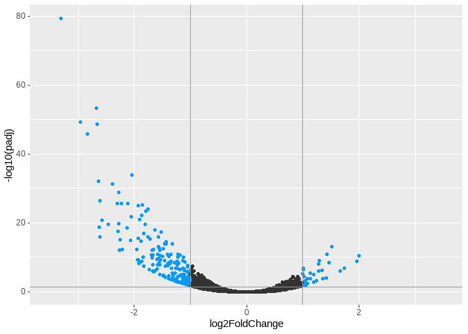

```r
res <- na.omit(res)

#volcano plot
res <- res %>%
  mutate(Significant = case_when(
    log2FoldChange > 1 & padj < 0.05 ~ "Yes",
    log2FoldChange > 1 & padj > 0.05 ~ "No",
    log2FoldChange < -1 & padj < 0.05 ~ "Yes",
    log2FoldChange < -1 & padj > 0.05 ~ "No",
    between(log2FoldChange, -1, 1) & padj < 0.05 ~ "No",
    between(log2FoldChange, -1, 1) & padj > 0.05 ~ "No"
  )
  )

#log2FC = 1 --> 2x more, 2 --> 4x more

res %>%
  ggplot(aes(x = log2FoldChange, y = -log10(padj), colour = Significant)) +
  geom_point() +
  coord_cartesian(x=c(-3.5,3.5)) +
  geom_vline(xintercept = c(-1, 1), color = "#999999") +
  geom_hline(yintercept = c(-log10(0.05)), color = "#999999") +
  scale_colour_manual(values = c("#333333", "#0099ff"), guide=F)
```

Loading all res files from all comparisons:

```r
#res_all <- list.files(pattern = "res.csv$", recursive = TRUE) --> doesn't work, but works in console.

#list.files() --> directory is the R folder for some reason, even tho here(), and getwd() is ibd_steiner. Will have to put in absolute path itself

res_all <- list.files(path = "Z:/Nikita/Projects/ibd_steiner", pattern = "res.csv$", recursive = TRUE)

res_all
```

```
## [1] "data/DESeq2/Day-10_vs_ALI_Day7/Day10_vs_ALID7.deseq.res.csv"
## [2] "data/DESeq2/Day-10_vs_FliC-RD1/Day10_vs_FliCRD1D3.deseq.res.csv"
## [3] "data/DESeq2/Day-10_vs_FliC-RD5/Day10_vs_FliCRD5D3.deseq.res.csv"
## [4] "data/DESeq2/Day-10_vs_US-RD1/Day10_vs_USRD1D3.deseq.res.csv"
## [5] "data/DESeq2/Day-10_vs_US-RD5/Day10_vs_USRD5D3.deseq.res.csv"
## [6] "data/DESeq2/US-RD1_vs_FliC-RD1/USRD1D3_vs_FliCRD1D3.deseq.res.csv"
## [7] "data/DESeq2/US-RD5_vs_FliC-RD5/USRD5D3_vs_FliCRD5D3.deseq.res.csv"
## [8] "data/DESeq2/US-RD5_vs_US-RD1/USRD5D3_vs_USRD1D3.deseq.res.csv"
## [9] "data/DESeq2/zFliC-RD5_vs_FliC-RD1/FliCRD5D3_vs_FliCRD1D3.deseq.res.csv"
```

```r
res_all <- lapply(res_all, utils::read.csv)

#need to setwd to ibd_steiner + also check Knit directory and change to working directory

df_names <- c("d10_alid7", "d10_flicRD1", "d10_flicRD5", "d10_RD1", "d10_RD5", "RD1_flicRD1", "RD5_flicRD5", "RD5_RD1", "flicRD5_flicRD1")

names(res_all) <- df_names
```

### 4.0 Making the expression and phenotype dataframes

#### 4.1 Making pDat

```r
pDat <- data.frame("Sample_ID" = c("59C", "75C"), "Sample_Number" = c("1", "2"), "Sex" = c("Female", "Male"), "Age" = c(49, 58), "Biopsy_Region" = c("Transverse", "Ascending"))

pDat <- pDat %>%
  slice(rep(1:n(), each = 6)) #since we have 6 conditions, and 2 samples for each condition

pDat <- as.data.frame(t(pDat))

df_names_all <- c("59C_Day10", "59C_ALI_Day7", "59C_US_RD1", "59C_US_RD5", "59C_flic_RD1", "59C_flicRD5", "75C_Day10", "75C_ALI_Day7", "75C_US_RD1", "75C_US_RD5", "75C_flic_RD1", "75C_flicRD5")
colnames (pDat) <- df_names_all
pDat <- pDat [-1,]

pDat <- as.data.frame(t(pDat))

pDat$Condition <- as.factor(c("Day_10", "ALI_Day7", "US_RD1", "US_RD5", "flic_RD1", "flicRD5"))
pDat$Condition <- fct_relevel(c("Day_10", "ALI_Day7", "US_RD1", "US_RD5", "flic_RD1", "flicRD5"))

condition_level <- c("Day_10", "ALI_Day7", "US_RD1", "US_RD5", "flic_RD1", "flic_RD5")

pDat <- pDat %>%
  dplyr::arrange(factor(Condition, levels = condition_level))

pDat <- pDat %>%
  rownames_to_column(var = "group")

pDat$ID <- pDat$group
pDat$ID <- str_sub(pDat$ID, 1, 3)
pDat$ID <- as.factor(pDat$ID)

str(pDat)
```

```
## 'data.frame':    12 obs. of  7 variables:
##  $ group        : chr  "59C_Day10" "75C_Day10" "59C_ALI_Day7" "75C_ALI_Day7" ...
##  $ Sample_Number: chr  "1" "2" "1" "2" ...
##  $ Sex          : chr  "Female" "Male" "Female" "Male" ...
##  $ Age          : chr  "49" "58" "49" "58" ...
##  $ Biopsy_Region: chr  "Transverse" "Ascending" "Transverse" "Ascending" ...
##  $ Condition    : Factor w/ 6 levels "ALI_Day7","Day_10",..: 2 2 1 1 5 5 6 6 3 3 ...
##  $ ID           : Factor w/ 2 levels "59C","75C": 1 2 1 2 1 2 1 2 1 2 ...
```

```r
pDat <- pDat %>%
  column_to_rownames(var = "group")

#write.xlsx(pDat, file = here::here("data", "Processed", "ibd_pDat.xlsx"), col.names = TRUE, row.names = TRUE)
```

#### 4.2 Making eDat

```r
#reading in raw counts
raw <- list.files(pattern = ".counts.csv$", recursive = TRUE)
raw <- map(raw, read.csv)
names(raw) <- df_names
raw <- map(raw, function(x) {colnames(x)[1] <- "gene"; x} )

#binding all raw counts to create one df
eDat <- raw[[1]] #using d10_ali7 as base df

eDat <- eDat %>%
  inner_join(raw[[8]]) %>%  # joining RD1 and RD5 counts
  inner_join(raw[[9]]) #joining flicRD1 and flicRD5 counts

eDat <- eDat %>%
  as.tibble() %>%
  tibble::column_to_rownames(var = "gene")

eDat <- eDat %>%
  dplyr::select(1,3,5,7,9,11, everything())

#order is all messed up
#RD1 vs RD5 is 59C, 75C, 75C, 59C
eDat <- eDat %>%
  dplyr::select(1,2,4,3,6,5,7,8,10,9,12,11)

eDat <- eDat %>%
  dplyr::select(1,2,9,4:8,3,10:12)
names(eDat)
```

```
##  [1] "X59C.Day.10"      "X59C.ALI.D7"      "X59C.US.RD1.D3"   "X59C.US.RD5.D3"
##  [5] "X59C.FliC.RD1.D3" "X59C.FliC.RD5.D3" "X75C.Day.10"      "X75C.ALI.D7"
##  [9] "X75C.US.RD1.D3"   "X75C.US.RD5.D3"   "X75C.FliC.RD1.D3" "X75C.FliC.RD5.D3"
```

```r
colnames(eDat) <- row.names(pDat)

dim(eDat) #26,364 genes
```

```
## [1] 26364    12
```

```r
eDat <- eDat %>%
  rownames_to_column(var = "gene")
#write.xlsx(eDat, file = here::here("data", "Processed", "ibd_eDat_raw.xlsx"), col.names = TRUE, row.names = TRUE)

eDat <- eDat %>%
  column_to_rownames(var = "gene")

#RLE norm
genes <- as.data.frame(row.names(eDat))
norm <- DGEList(counts = eDat, samples = pDat, genes = genes)
eDat_norm <- calcNormFactors(norm, method = "RLE")
eDat_norm <- cpm(eDat_norm)
eDat_norm <- as.data.frame(eDat_norm)

eDat_norm <- eDat_norm %>%
  rownames_to_column(var = "gene")

#filtering by at least 0.01 count in all samples
eNorm <- eDat_norm %>%
  filter_if(is.numeric, all_vars(. > 0.01)) %>%
  #otherwise we loose genes that in one condition might have very low, but quite high in the others (eg  REN)
  column_to_rownames(var = "gene")

dim(eNorm) #14,173 genes
```

```
## [1] 14173    12
```

```r
#write.xlsx(eNorm, file = here::here("data", "Processed", "ibd_eDat_norm.xlsx"), col.names = TRUE, row.names = TRUE)

eDat_norm <- eDat_norm %>%
  column_to_rownames(var = "gene")

#log2 transform counts for vizualization
eNorm_log2 <- log2(eNorm)
```

### 5.0 Exploratory Analysis

#### 5.1 Volcano Plots

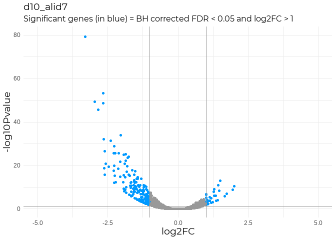

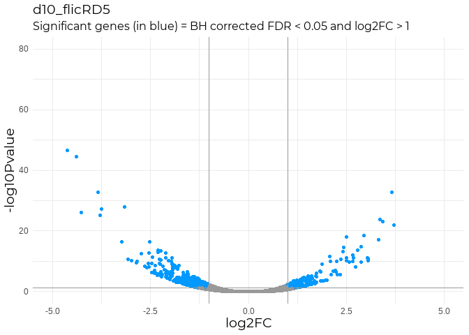

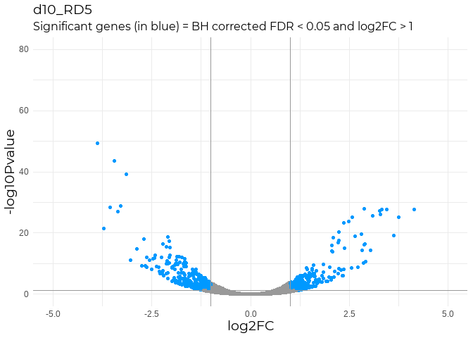

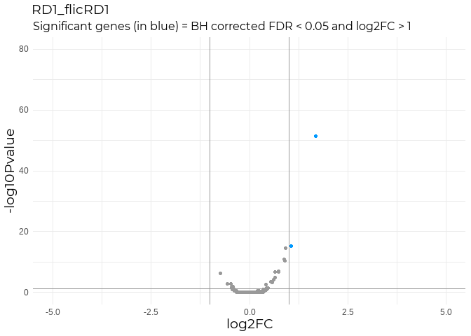

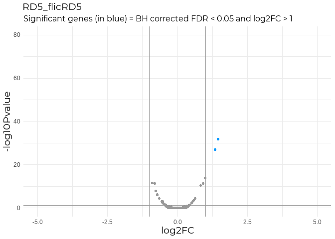

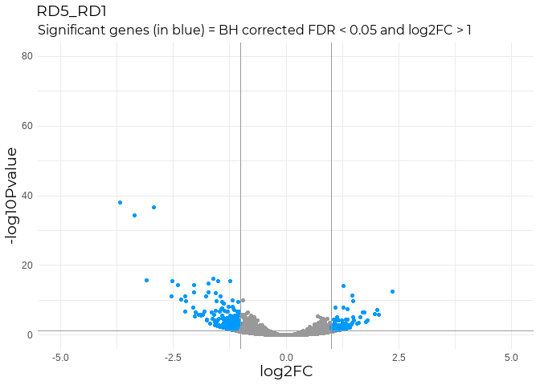

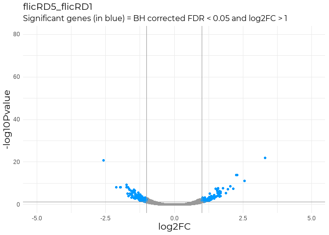

```r
#removing all NAs
res_all <- lapply(res_all, na.omit)

#function to make the significance column for each df in the list
sign_column <- function(x) {
  x %>%
    dplyr::mutate(Significant = case_when(
      log2FoldChange > 1 & padj < 0.05 ~ "Yes",
      log2FoldChange > 1 & padj > 0.05 ~ "No",
      log2FoldChange < -1 & padj < 0.05 ~ "Yes",
      log2FoldChange < -1 & padj > 0.05 ~ "No",
      between(log2FoldChange, -1, 1) & padj < 0.05 ~ "No",
      between(log2FoldChange, -1, 1) & padj > 0.05 ~ "No"
    )
    )
}

res_all <- lapply(res_all, sign_column)

vplots <- list() #creating an empty list to store all the plots.

#for loop to make plots for each miRNA. Cannot figure out how to wr loop in a function
for (i in seq_along(res_all)){
  x <- ggplot(res_all[[i]], aes(x = log2FoldChange, y = -log10(padj), colour = Significant)) +
    geom_point() +
    coord_cartesian(x=c(-5,5), y=c(0,80)) +
    geom_vline(xintercept = c(-1, 1), color = "#999999") +
    geom_hline(yintercept = c(-log10(0.05)), color = "#999999") +
    scale_colour_manual(values = c("#999999", "#0099ff"), guide = F) +
    labs(x = "log2FC", y = "-log10Pvalue", subtitle = "Significant genes (in blue) = BH corrected FDR < 0.05 and log2FC > 1") +
    ggtitle(names(res_all[i])) +
    my_theme
  vplots[[i]] <- x
}

names(vplots) <- df_names

#vplots
#Hmm, the y-axis is too small for all but d10_RD1 and d10_flicRD1. Let's take those two out and plot them separately.

d10_RD1 <- res_all[[4]]

d10_flicRD1 <- res_all[[2]]

vplots[c("d10_RD1", "d10_flicRD1")] <- NULL

gd10_RD1 <- d10_RD1 %>%
  ggplot(aes(x = log2FoldChange, y = -log10(padj), colour = Significant)) +
  geom_point() +
  coord_cartesian(x=c(-5,5), y=c(0,175)) +
  geom_vline(xintercept = c(-1, 1), color = "#999999") +
  geom_hline(yintercept = c(-log10(0.05)), color = "#999999") +
  scale_colour_manual(values = c("#999999", "#0099ff"), guide = F) +
  labs(x = "log2FC", y = "-log10Pvalue", title = "d10_RD1", subtitle = "Significant genes (in blue) = BH corrected FDR < 0.05 and log2FC > 1") +
  my_theme

gd10_flicRD1 <- d10_flicRD1 %>%
  ggplot(aes(x = log2FoldChange, y = -log10(padj), colour = Significant)) +
  geom_point() +
  coord_cartesian(x=c(-5,5), y=c(0,100)) +
  geom_vline(xintercept = c(-1, 1), color = "#999999") +
  geom_hline(yintercept = c(-log10(0.05)), color = "#999999") +
  scale_colour_manual(values = c("#999999", "#0099ff"), guide = F) +
  labs(x = "log2FC", y = "-log10Pvalue", title = "d10_flicRD1", subtitle = "Significant genes (in blue) = BH corrected FDR < 0.05 and log2FC > 1") +
  my_theme

vplots
```